Skip to main content

# Analyse der Artenzahl und Umweltvariablen unter Berücksichtigung räumlicher Autokorrelation

Author

Linnert Franz

Published

November 9, 2026

## 1 Einleitung

In dieser Analyse untersuchen wir die Artenzahl (Speziesreichtum) von 70 Probeflächen im Zusammenhang mit hydrochemischen und geographischen Umweltvariablen (u. a. pH-Wert, Leitfähigkeit, Calcium, Magnesium). Wir prüfen, welche Umweltvariablen ohne Raumberücksichtigung signifikant mit der Artenzahl korrelieren und ob diese Zusammenhänge nach einer räumlichen Korrektur (mittels modifiziertem t-Test nach Clifford et al. via `SpatialPack`) bestehen bleiben.

## 2 Datenimport und Aufbereitung

Die Daten der Arten-Matrix (`species.txt`) und der Umweltfaktoren (`environment.txt`) werden eingelesen. Aus der Arten-Matrix berechnen wir für jede Probefläche die Gesamtzahl der vorkommenden Arten (Speziesreichtum). Zudem stellen wir die Untersuchungsstandorte interaktiv auf einer Karte dar.

```r
# Vorgegebene Pakete laden
library(corrplot)    # Visualisierung von Korrelationsmatrizen
library(SpatialPack) # Räumlich korrigierte Korrelationen (Clifford et al.)
library(terra)       # Vektordaten & Koordinatentransformationen
library(mapview)     # Interaktive Karten
library(MASS)        # Anpassung von Normalverteilungen / Statistische Methoden
library(vegan)       # Unähnlichkeiten, Diversitätsmaße und Mantel-Test

# 1. Daten aus den Textdateien einlesen
species_matrix <- read.table("species.txt", header = TRUE, row.names = 1)
env <- read.table("environment.txt", header = TRUE, row.names = 1)

# 2. Artenzahl (Richness) pro Probefläche berechnen
species_richness <- rowSums(species_matrix > 0)

# 3. Umweltdaten und Artenzahl zusammenführen
df <- data.frame(env, Richness = species_richness)

# 4. Räumliches Objekt (terra) erstellen
coords_vect <- vect(df, geom = c("lon", "lat"), crs = "EPSG:4326")

# 5. Interaktive Karte mit Hintergrundkarte und Artenzahl-Einfärbung
mapview(
  coords_vect,
  zcol = "Richness",                                    # Farbe nach Artenzahl
  cex = "Richness",                                     # Punktegröße nach Artenzahl
  map.types = c("OpenTopoMap", "Esri.WorldGrayCanvas"), # Hintergrundkarten auswählen
  layer.name = "Artenzahl"                              # Beschriftung in der Legende
)
```

[interactive chart not shown]

## 3 Standard-Korrelationsanalyse (ohne Raumkorrektur)

Wir berechnen zunächst die gewöhnlichen Pearson-Korrelationen zwischen der Artenzahl (`Richness`) und den Umweltvariablen, um zu sehen, welche Faktoren scheinbar mit der Artenzahl zusammenhängen.

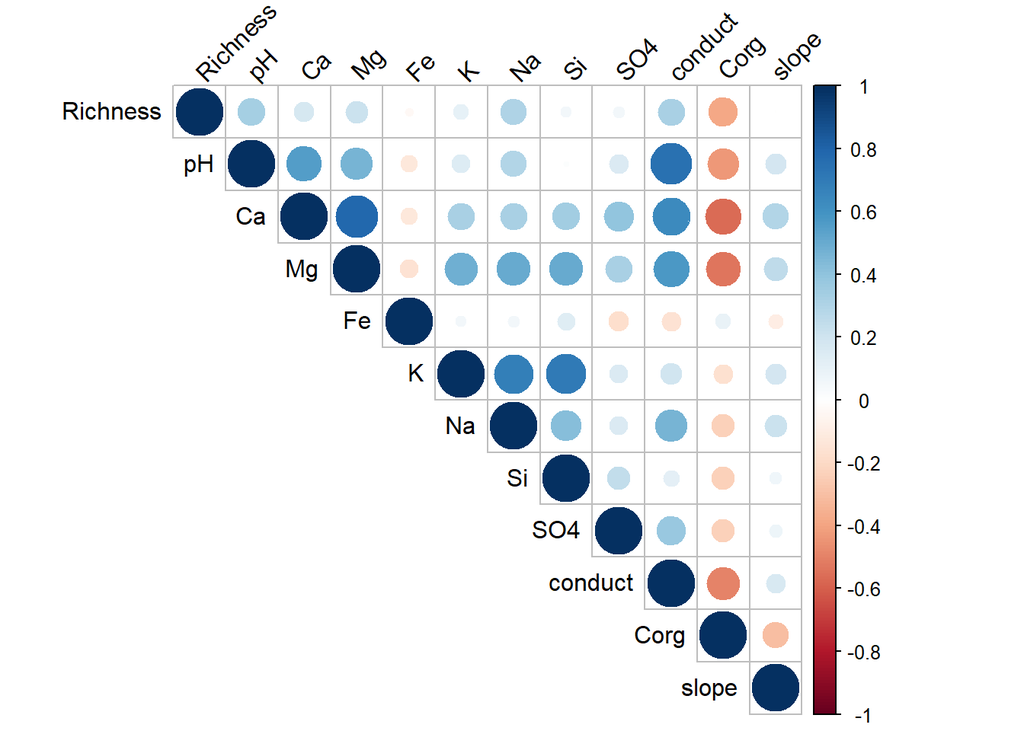

Pearson-Korrelationsmatrix zwischen Umweltvariablen und Artenzahl.

```r
# Auswahl numerischer Umweltvariablen
env_num <- df[, c("Richness", "pH", "Ca", "Mg", "Fe", "K", "Na", "Si", "SO4", "conduct", "Corg", "slope")]

# Korrelationsmatrix berechnen und visualisieren
cor_matrix <- cor(env_num, use = "complete.obs")
corrplot(cor_matrix, method = "circle", type = "upper", tl.col = "black", tl.srt = 45)
```